# Tidyverse

September 2021

## Tidyverse

### `ggolot2`

- Install the packages `install.packages(c("ggplot2", "gapminder"), dependencies = TRUE)`
- Load the packages:

```r
library(gapminder); library(ggplot2)
data(package = 'gapminder')
data("gapminder")
gapminder #panel data on life expectancy, population size, and GDP per capita for 142 countries since the 1950s.
```

```
## # A tibble: 1,704 x 6
##    country     continent  year lifeExp      pop gdpPercap
##    <fct>       <fct>     <int>   <dbl>    <int>     <dbl>
##  1 Afghanistan Asia       1952    28.8  8425333      779.
##  2 Afghanistan Asia       1957    30.3  9240934      821.
##  3 Afghanistan Asia       1962    32.0 10267083      853.
##  4 Afghanistan Asia       1967    34.0 11537966      836.
##  5 Afghanistan Asia       1972    36.1 13079460      740.
##  6 Afghanistan Asia       1977    38.4 14880372      786.
##  7 Afghanistan Asia       1982    39.9 12881816      978.
##  8 Afghanistan Asia       1987    40.8 13867957      852.
##  9 Afghanistan Asia       1992    41.7 16317921      649.
## 10 Afghanistan Asia       1997    41.8 22227415      635.
## # ... with 1,694 more rows
```

- Creating a ggplot

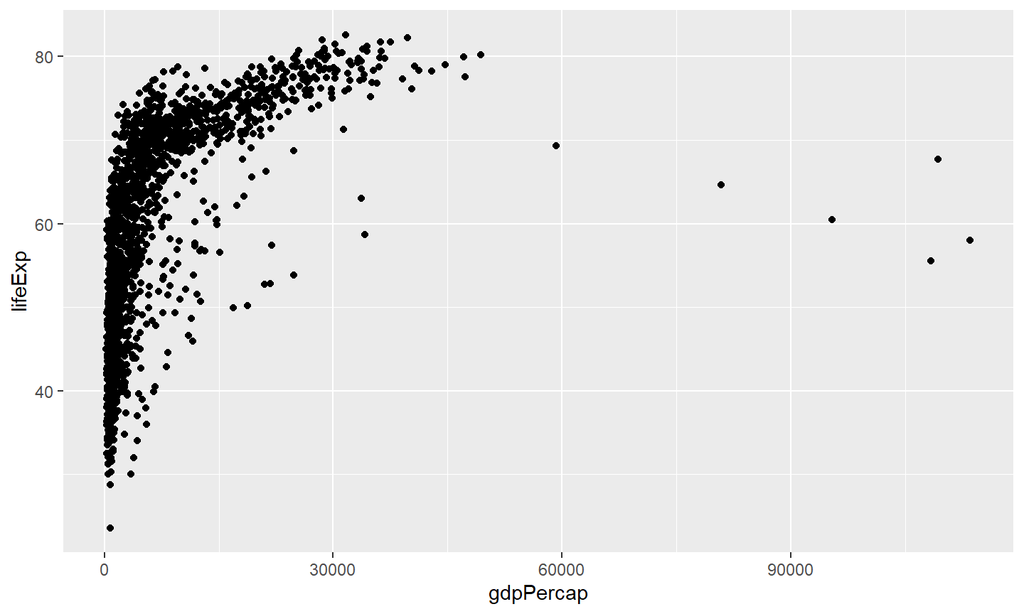

```r
ggplot(data = gapminder)+
  geom_point(mapping =  aes(x = gdpPercap, y = lifeExp))
```

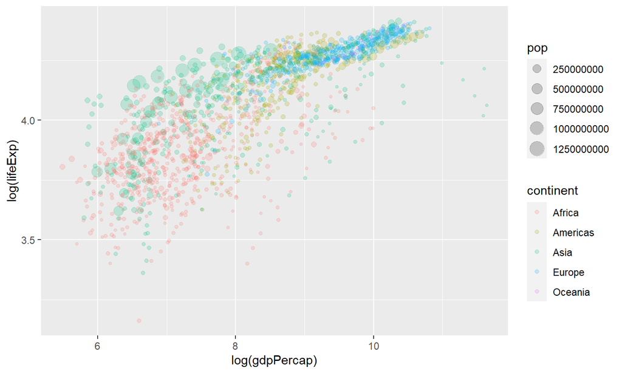

```r
ggplot(data = gapminder, aes(log(gdpPercap), log(lifeExp)))+ # Global aesthetic mapping
  geom_point(mapping =  aes(col = continent, size = pop),
             alpha = 0.2)
```

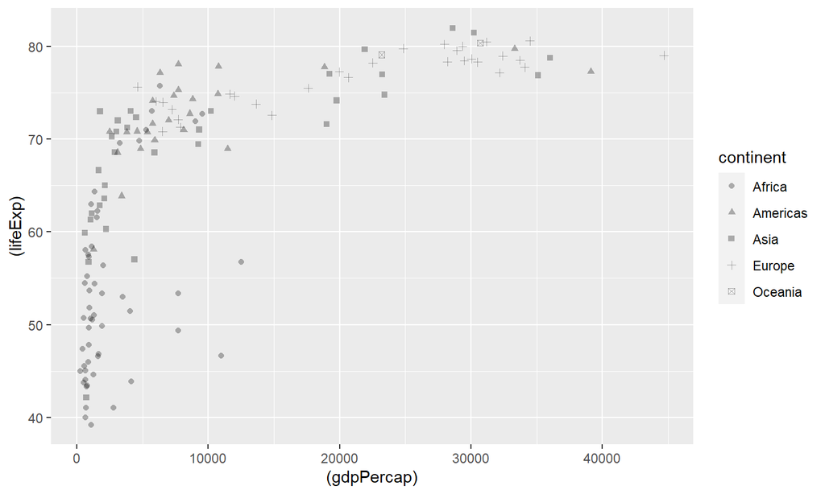

```r
ggplot(data = filter(gapminder, year == 2002), aes((gdpPercap), (lifeExp)))+ # Global aesthetic mapping
  geom_point(aes(shape = continent),  alpha = 0.3)
```

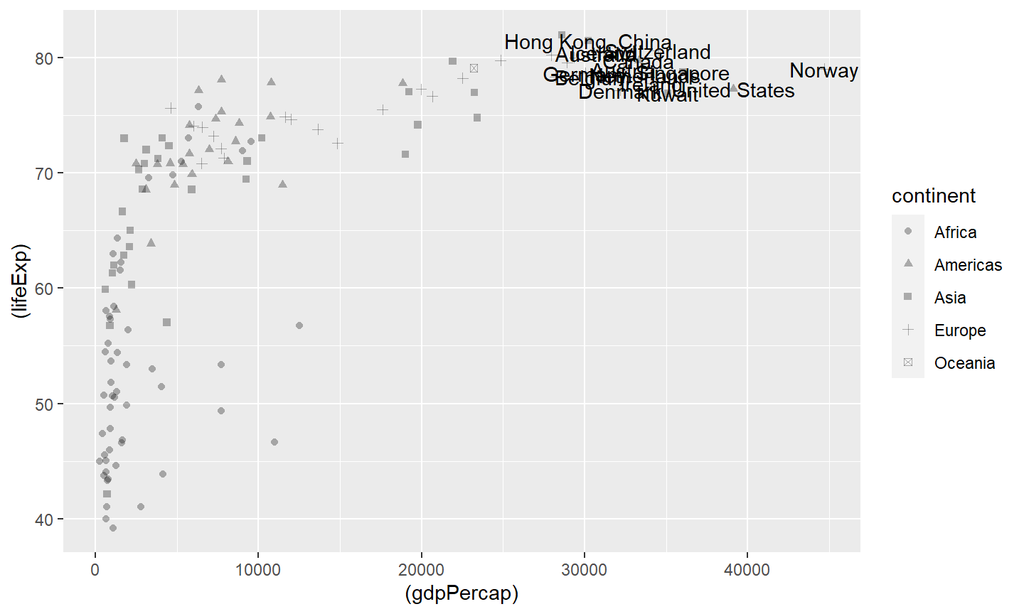

```r
ggplot(data = filter(gapminder, year == 2002), aes((gdpPercap), (lifeExp)))+ # Global aesthetic mapping
  geom_point(aes(shape = continent),  alpha = 0.3)+
  geom_text(aes(label =if_else(gdpPercap > 30000 & lifeExp > 75, as.character(country), "")))
```

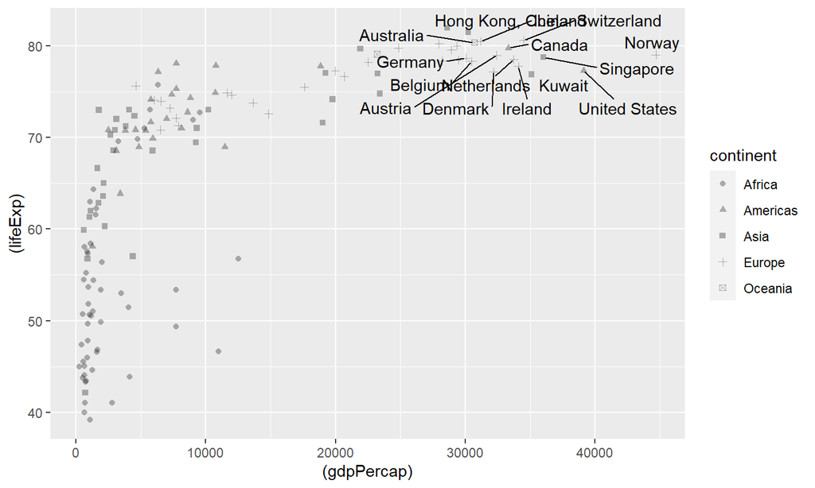

```r
library(ggrepel) # text labels repels away from each other
ggplot(data = filter(gapminder, year == 2002), aes((gdpPercap), (lifeExp)))+ # Global aesthetic mapping
  geom_point(aes(shape = continent),  alpha = 0.3)+
  geom_text_repel(aes(label =if_else(gdpPercap > 30000 & lifeExp > 75, as.character(country), "")), max.overlaps = 35)
```

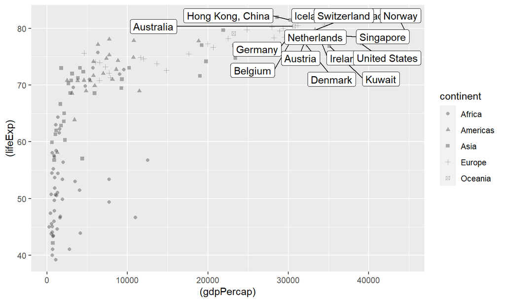

```r
library(ggrepel) # text labels repels away from each other
ggplot(data = filter(gapminder, year == 2002), aes((gdpPercap), (lifeExp)))+ # Global aesthetic mapping
  geom_point(aes(shape = continent),  alpha = 0.3)+
  geom_label_repel(aes(label =if_else(gdpPercap > 30000 & lifeExp > 75, as.character(country), "")), max.overlaps = 35)
```

`nudge_x` and `nudge_y`

- Use the `nudge_x` and the `nudge_y` arguments to repel better.
- Both the arguments use their respective units on the x-axis and the y-axis.
- Try the previous example with the values of
  - `nudge_x =` -3000
  - `nudge_y =` -15

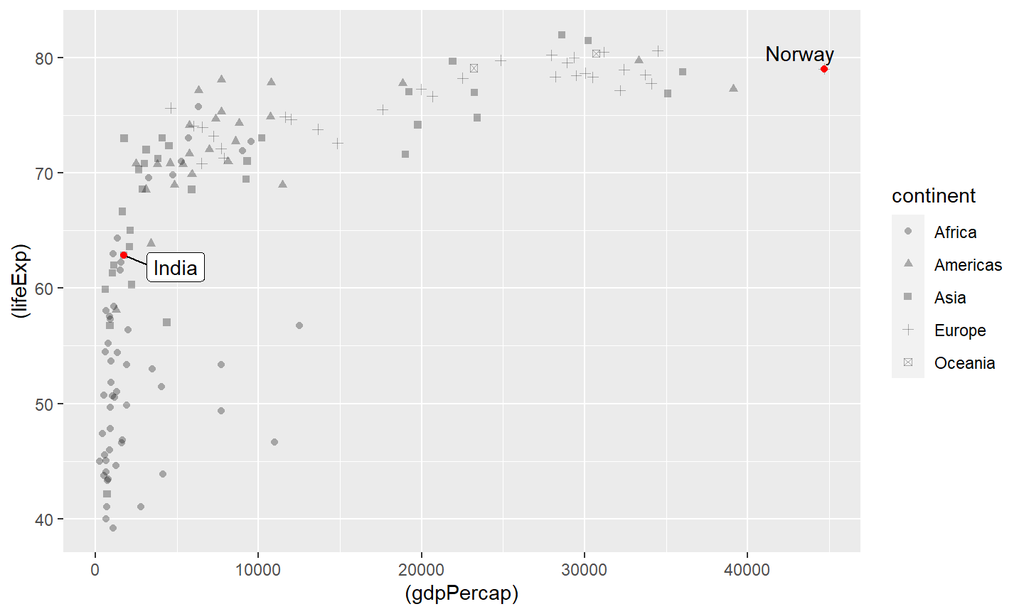

```r
library(ggrepel) # text labels repels away from each other
ggplot(data = filter(gapminder, year == 2002), aes((gdpPercap), (lifeExp)))+ # Global aesthetic mapping
  geom_point(aes(shape = continent),  alpha = 0.3)+
  geom_text_repel(aes(label =if_else(gdpPercap > 40000 & lifeExp > 75, as.character(country), "")), max.overlaps = 35, nudge_x = 0.1, nudge_y = 0.1)+
  geom_point(aes(x = filter(gapminder, year == 2002, gdpPercap > 40000 & lifeExp > 75)$gdpPercap,y = filter(gapminder, year == 2002, gdpPercap > 40000 &lifeExp > 75)$lifeExp), col = "red")+
  geom_label_repel(aes(label =if_else(country == "India", as.character(country), "")), max.overlaps = 35, nudge_x = 0.1, nudge_y = 0.1)+
  geom_point(aes(x = filter(gapminder, year == 2002, country == "India")$gdpPercap,y = filter(gapminder, year == 2002, country == "India")$lifeExp), col = "red")
```

Facets (wrap)

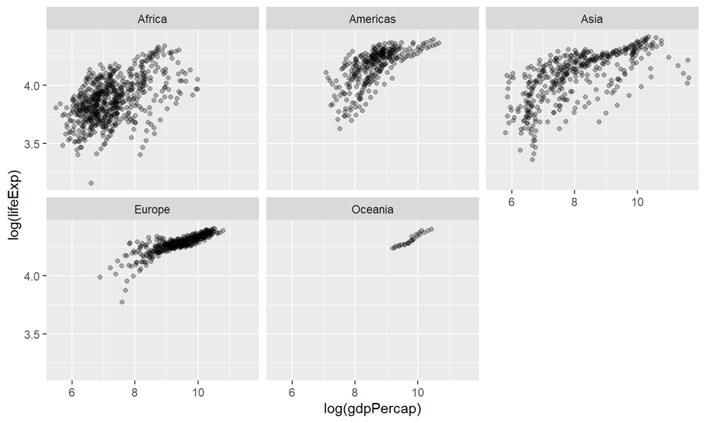

```r
ggplot(gapminder) +
  geom_point(aes(log(gdpPercap), log(lifeExp)), alpha = 0.3)+
  facet_wrap(~ continent)
```

Facets (grid)

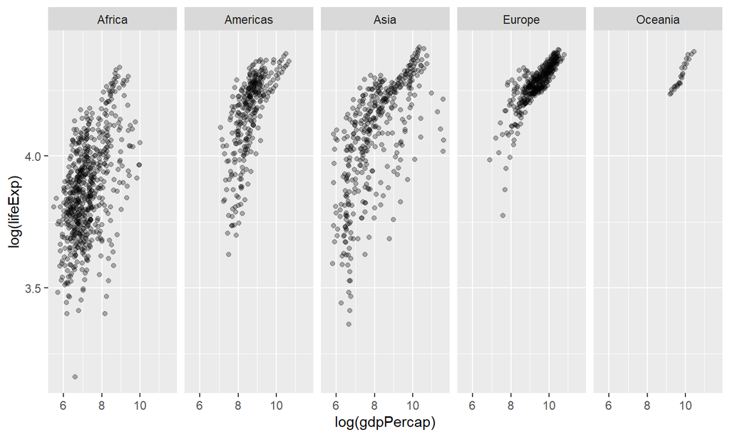

```r
ggplot(gapminder) +
  geom_point(aes(log(gdpPercap), log(lifeExp)), alpha = 0.3)+
  facet_grid(. ~ continent)
```

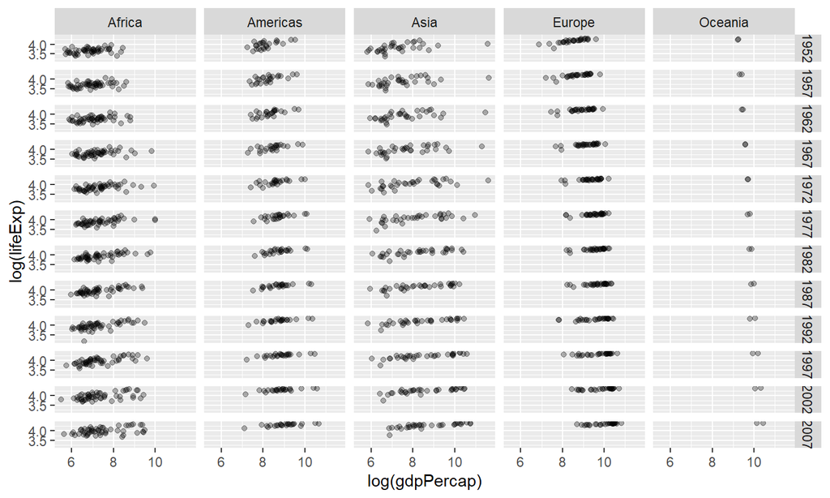

```r
ggplot(gapminder) +
  geom_point(aes(log(gdpPercap), log(lifeExp)), alpha = 0.3)+
  facet_grid(year ~ continent)
```

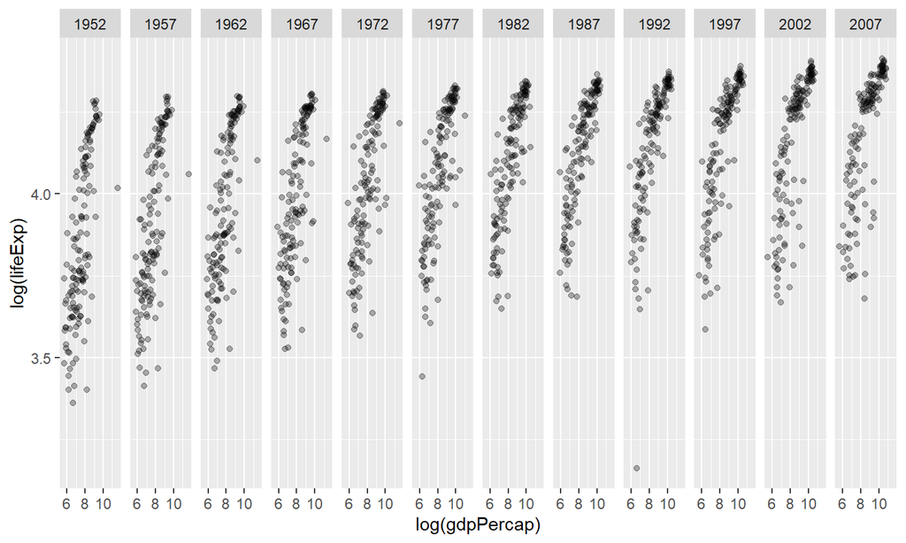

```r
ggplot(gapminder) +
  geom_point(aes(log(gdpPercap), log(lifeExp)), alpha = 0.3)+
  facet_grid(. ~ year)
```

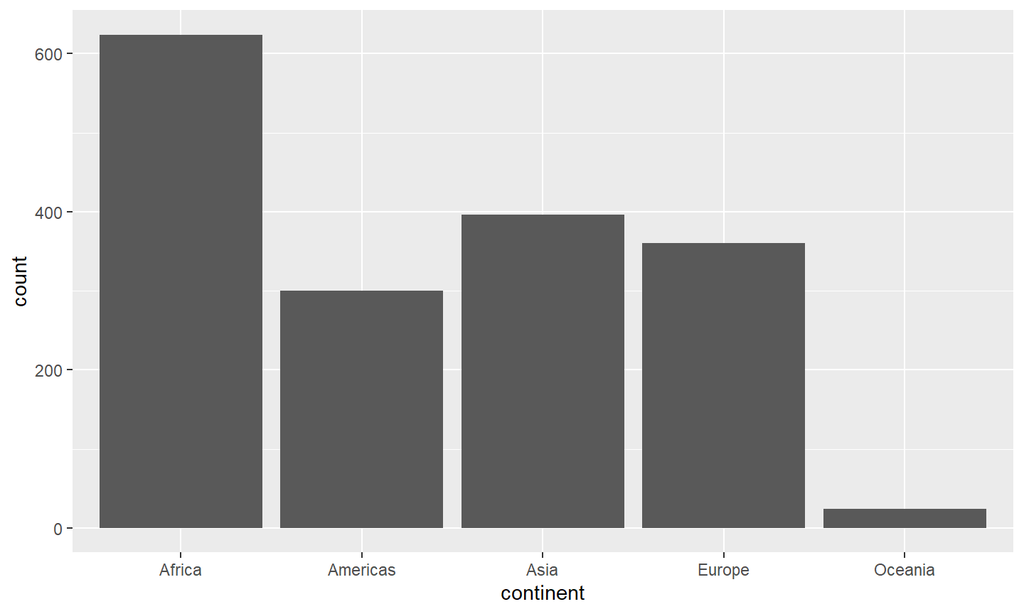

```r
ggplot(filter(gapminder))+
  geom_bar(aes(continent), stat = "count") # the bars
```

```r
(Population <- filter(gapminder, year == 2007) %>%
  group_by(continent) %>%
  summarise(popu = round(sum(pop/1000000000),2)))
```

```
## # A tibble: 5 x 2
##   continent  popu
##   <fct>     <dbl>
## 1 Africa     0.93
## 2 Americas   0.9
## 3 Asia       3.81
## 4 Europe     0.59
## 5 Oceania    0.02
```

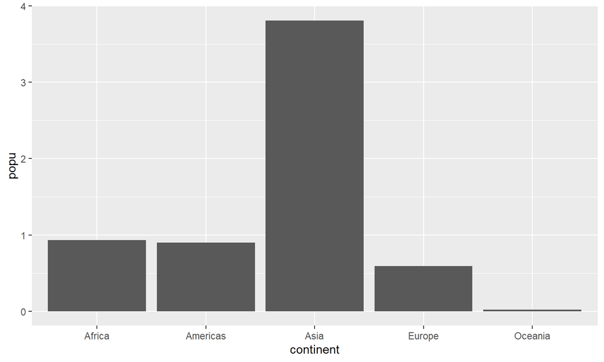

```r
Population %>%
ggplot(aes(continent, popu))+
  geom_bar( stat = "identity") # the bars are the population figures w.r.t the continents
```

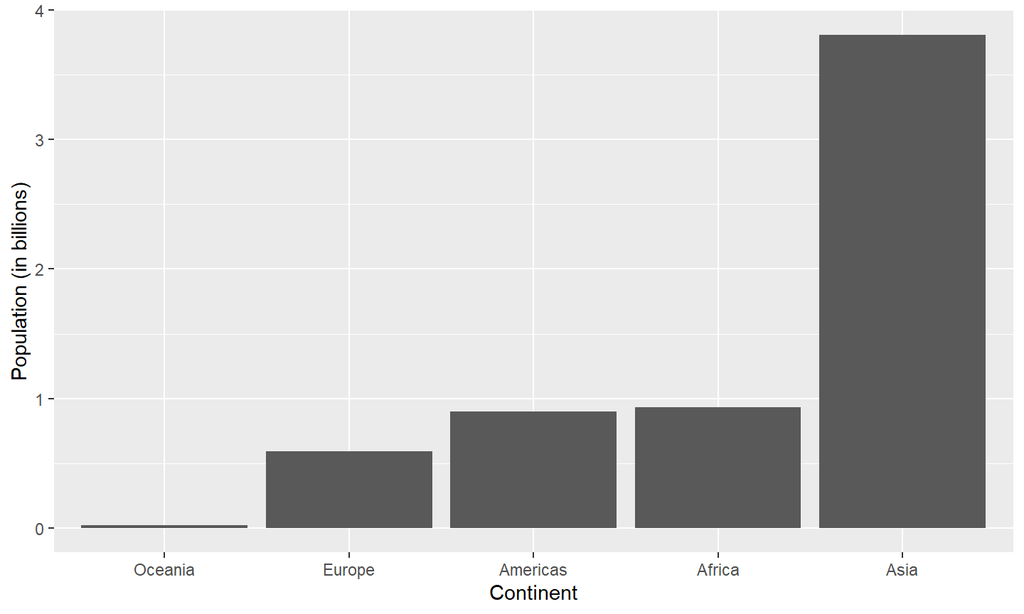

```r
# reorder() from base package
Population %>%
ggplot(aes(reorder(continent, popu), popu))+
  geom_bar(stat = "identity") +
  labs(x = "Continent",
       y = "Population (in billions)")
```

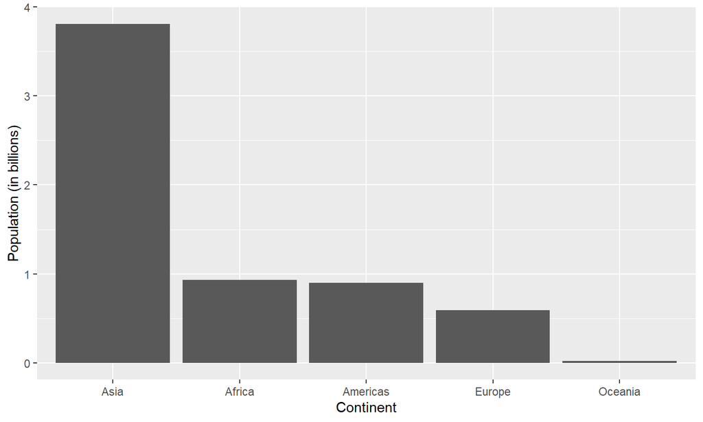

```r
# reorder() from base package
Population %>%
ggplot(aes(reorder(continent, -popu), popu))+
  geom_bar(stat = "identity") +
  labs(x = "Continent",
       y = "Population (in billions)")
```

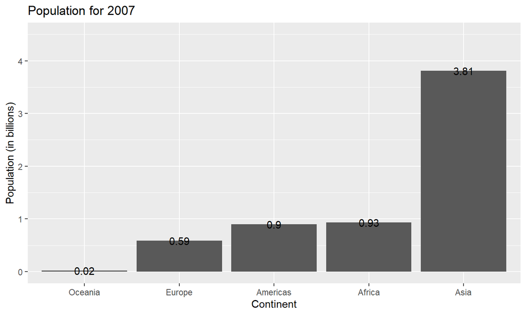

```r
 Population %>%
   ggplot(aes(reorder(continent, popu), popu))+
   geom_bar(stat = "identity")+
   geom_text(aes(label = popu))+
   expand_limits(y = c(0, 4.5)) +
   labs(x = "Continent", y = "Population (in billions)",
        title = "Population for 2007")
```

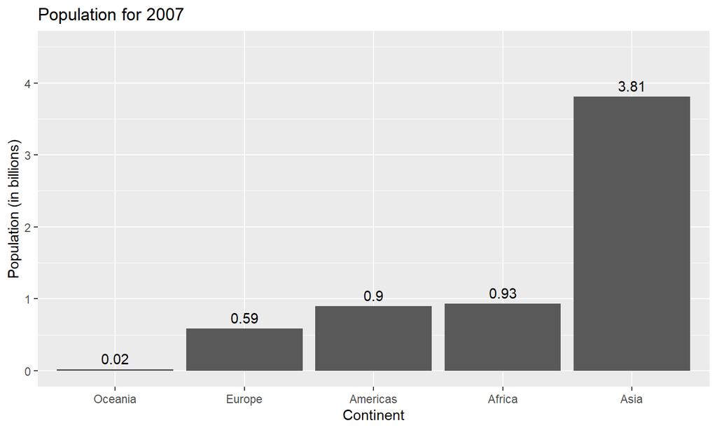

```r
 Population %>%
   ggplot(aes(reorder(continent, popu), popu))+
   geom_bar(stat = "identity")+
   geom_text(aes(label = popu),
                   vjust = - 0.5)+
   expand_limits(y = c(0, 4.5)) +
   labs(x = "Continent", y = "Population (in billions)",
        title = "Population for 2007")
```

```r
(Population_prop <- Population %>%
   mutate(propo = round(popu/sum(popu),3)))
```

```
## # A tibble: 5 x 3
##   continent  popu propo
##   <fct>     <dbl> <dbl>
## 1 Africa     0.93 0.149
## 2 Americas   0.9  0.144
## 3 Asia       3.81 0.61
## 4 Europe     0.59 0.094
## 5 Oceania    0.02 0.003
```

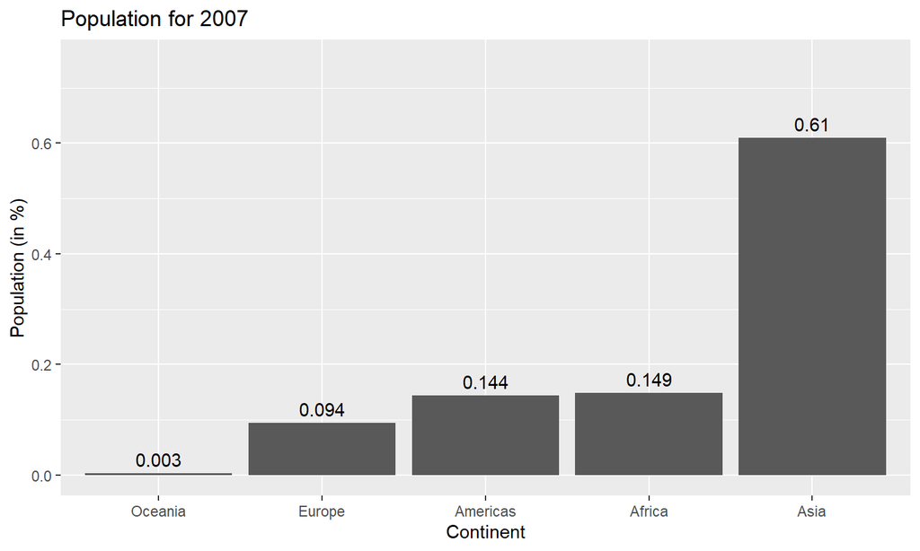

```r
 Population_prop %>%
   ggplot(aes(reorder(continent, propo),propo))+
  geom_bar(stat = "identity")+
  expand_limits(y = c(0,0.75))+
  geom_text(aes(label = propo), vjust = -0.5)+
   labs(x = "Continent", y = "Population (in %)",
        title = "Population for 2007")
```

We will do more plots later!

## Tidyverse

### Data transformation

**Packages and Data**

- `dplyr` package
  - `filter()`, `arrange()`, `select()`, `mutate()`, `summarise()` functions/verbs.
- `library(tidyverse)`
- `gapminder` data set

```r
library(gapminder)
data(gapminder)
gapminder
```

```
## # A tibble: 1,704 x 6
##    country     continent  year lifeExp      pop gdpPercap
##    <fct>       <fct>     <int>   <dbl>    <int>     <dbl>
##  1 Afghanistan Asia       1952    28.8  8425333      779.
##  2 Afghanistan Asia       1957    30.3  9240934      821.
##  3 Afghanistan Asia       1962    32.0 10267083      853.
##  4 Afghanistan Asia       1967    34.0 11537966      836.
##  5 Afghanistan Asia       1972    36.1 13079460      740.
##  6 Afghanistan Asia       1977    38.4 14880372      786.
##  7 Afghanistan Asia       1982    39.9 12881816      978.
##  8 Afghanistan Asia       1987    40.8 13867957      852.
##  9 Afghanistan Asia       1992    41.7 16317921      649.
## 10 Afghanistan Asia       1997    41.8 22227415      635.
## # ... with 1,694 more rows
```

**Filter rows with `filter()`**

- Filter all the countries in Asia for 1952.

*Note that `==` is used for comparison and `=` for assignment.*

```r
filter(gapminder, continent == "Asia", year == 1952)
```

```
## # A tibble: 33 x 6
##    country          continent  year lifeExp       pop gdpPercap
##    <fct>            <fct>     <int>   <dbl>     <int>     <dbl>
##  1 Afghanistan      Asia       1952    28.8   8425333      779.
##  2 Bahrain          Asia       1952    50.9    120447     9867.
##  3 Bangladesh       Asia       1952    37.5  46886859      684.
##  4 Cambodia         Asia       1952    39.4   4693836      368.
##  5 China            Asia       1952    44   556263527      400.
##  6 Hong Kong, China Asia       1952    61.0   2125900     3054.
##  7 India            Asia       1952    37.4 372000000      547.
##  8 Indonesia        Asia       1952    37.5  82052000      750.
##  9 Iran             Asia       1952    44.9  17272000     3035.
## 10 Iraq             Asia       1952    45.3   5441766     4130.
## # ... with 23 more rows
```

- Find all the countries in Asia or Africa.

```r
## filter(gapminder, continent == "Asia" | continent == "Africa")
# or
filter(gapminder, continent %in% c("Asia", "Africa"))
```

```
## # A tibble: 1,020 x 6
##    country     continent  year lifeExp      pop gdpPercap
##    <fct>       <fct>     <int>   <dbl>    <int>     <dbl>
##  1 Afghanistan Asia       1952    28.8  8425333      779.
##  2 Afghanistan Asia       1957    30.3  9240934      821.
##  3 Afghanistan Asia       1962    32.0 10267083      853.
##  4 Afghanistan Asia       1967    34.0 11537966      836.
##  5 Afghanistan Asia       1972    36.1 13079460      740.
##  6 Afghanistan Asia       1977    38.4 14880372      786.
##  7 Afghanistan Asia       1982    39.9 12881816      978.
##  8 Afghanistan Asia       1987    40.8 13867957      852.
##  9 Afghanistan Asia       1992    41.7 16317921      649.
## 10 Afghanistan Asia       1997    41.8 22227415      635.
## # ... with 1,010 more rows
```

- `%in%` is used to see whether an object is contained within (i.e. matches one of) a list of items.

Find all the countries with per capita GDP between \(\$500\) and \(\$1000\).

```r
filter(gapminder, gdpPercap >= 500 & gdpPercap <= 1000 )
```

```
## # A tibble: 288 x 6
##    country     continent  year lifeExp      pop gdpPercap
##    <fct>       <fct>     <int>   <dbl>    <int>     <dbl>
##  1 Afghanistan Asia       1952    28.8  8425333      779.
##  2 Afghanistan Asia       1957    30.3  9240934      821.
##  3 Afghanistan Asia       1962    32.0 10267083      853.
##  4 Afghanistan Asia       1967    34.0 11537966      836.
##  5 Afghanistan Asia       1972    36.1 13079460      740.
##  6 Afghanistan Asia       1977    38.4 14880372      786.
##  7 Afghanistan Asia       1982    39.9 12881816      978.
##  8 Afghanistan Asia       1987    40.8 13867957      852.
##  9 Afghanistan Asia       1992    41.7 16317921      649.
## 10 Afghanistan Asia       1997    41.8 22227415      635.
## # ... with 278 more rows
```

**Arrange rows with `arrange()`**

- Sorts a variable in ascending or descending order.

```r
arrange(gapminder, lifeExp)
```

```
## # A tibble: 1,704 x 6
##    country      continent  year lifeExp     pop gdpPercap
##    <fct>        <fct>     <int>   <dbl>   <int>     <dbl>
##  1 Rwanda       Africa     1992    23.6 7290203      737.
##  2 Afghanistan  Asia       1952    28.8 8425333      779.
##  3 Gambia       Africa     1952    30    284320      485.
##  4 Angola       Africa     1952    30.0 4232095     3521.
##  5 Sierra Leone Africa     1952    30.3 2143249      880.
##  6 Afghanistan  Asia       1957    30.3 9240934      821.
##  7 Cambodia     Asia       1977    31.2 6978607      525.
##  8 Mozambique   Africa     1952    31.3 6446316      469.
##  9 Sierra Leone Africa     1957    31.6 2295678     1004.
## 10 Burkina Faso Africa     1952    32.0 4469979      543.
## # ... with 1,694 more rows
```

```r
arrange(gapminder, desc(lifeExp))
```

```
## # A tibble: 1,704 x 6
##    country          continent  year lifeExp       pop gdpPercap
##    <fct>            <fct>     <int>   <dbl>     <int>     <dbl>
##  1 Japan            Asia       2007    82.6 127467972    31656.
##  2 Hong Kong, China Asia       2007    82.2   6980412    39725.
##  3 Japan            Asia       2002    82   127065841    28605.
##  4 Iceland          Europe     2007    81.8    301931    36181.
##  5 Switzerland      Europe     2007    81.7   7554661    37506.
##  6 Hong Kong, China Asia       2002    81.5   6762476    30209.
##  7 Australia        Oceania    2007    81.2  20434176    34435.
##  8 Spain            Europe     2007    80.9  40448191    28821.
##  9 Sweden           Europe     2007    80.9   9031088    33860.
## 10 Israel           Asia       2007    80.7   6426679    25523.
## # ... with 1,694 more rows
```

**Select columns with `select()`**

- Select columns by name

```r
select(gapminder, year, pop, gdpPercap)
```

```
## # A tibble: 1,704 x 3
##     year      pop gdpPercap
##    <int>    <int>     <dbl>
##  1  1952  8425333      779.
##  2  1957  9240934      821.
##  3  1962 10267083      853.
##  4  1967 11537966      836.
##  5  1972 13079460      740.
##  6  1977 14880372      786.
##  7  1982 12881816      978.
##  8  1987 13867957      852.
##  9  1992 16317921      649.
## 10  1997 22227415      635.
## # ... with 1,694 more rows
```

- `select(gapminder, year:gdpPercap)`
- `select(gapminder, -(year:gdpPercap))`
- `select(gapminder, starts_with("c"))`
- `select(gapminder, ends_with("p"))`
- `select(gapminder, contains("life"))`

`rename()` is a variant of `select()` that keeps all the variables that aren’t explicitly mentioned.

```r
rename(gapminder, perCapInc = gdpPercap)
```

```
## # A tibble: 1,704 x 6
##    country     continent  year lifeExp      pop perCapInc
##    <fct>       <fct>     <int>   <dbl>    <int>     <dbl>
##  1 Afghanistan Asia       1952    28.8  8425333      779.
##  2 Afghanistan Asia       1957    30.3  9240934      821.
##  3 Afghanistan Asia       1962    32.0 10267083      853.
##  4 Afghanistan Asia       1967    34.0 11537966      836.
##  5 Afghanistan Asia       1972    36.1 13079460      740.
##  6 Afghanistan Asia       1977    38.4 14880372      786.
##  7 Afghanistan Asia       1982    39.9 12881816      978.
##  8 Afghanistan Asia       1987    40.8 13867957      852.
##  9 Afghanistan Asia       1992    41.7 16317921      649.
## 10 Afghanistan Asia       1997    41.8 22227415      635.
## # ... with 1,694 more rows
```

**Add new variables with `mutate()`**

```r
mutate(gapminder, gdp = gdpPercap*pop)
```

```
## # A tibble: 1,704 x 7
##    country     continent  year lifeExp      pop gdpPercap          gdp
##    <fct>       <fct>     <int>   <dbl>    <int>     <dbl>        <dbl>
##  1 Afghanistan Asia       1952    28.8  8425333      779.  6567086330.
##  2 Afghanistan Asia       1957    30.3  9240934      821.  7585448670.
##  3 Afghanistan Asia       1962    32.0 10267083      853.  8758855797.
##  4 Afghanistan Asia       1967    34.0 11537966      836.  9648014150.
##  5 Afghanistan Asia       1972    36.1 13079460      740.  9678553274.
##  6 Afghanistan Asia       1977    38.4 14880372      786. 11697659231.
##  7 Afghanistan Asia       1982    39.9 12881816      978. 12598563401.
##  8 Afghanistan Asia       1987    40.8 13867957      852. 11820990309.
##  9 Afghanistan Asia       1992    41.7 16317921      649. 10595901589.
## 10 Afghanistan Asia       1997    41.8 22227415      635. 14121995875.
## # ... with 1,694 more rows
```

Keep only required columns/variables with `transmute()`.

```r
transmute(gapminder, gdp = gdpPercap*pop)
```

```
## # A tibble: 1,704 x 1
##             gdp
##           <dbl>
##  1  6567086330.
##  2  7585448670.
##  3  8758855797.
##  4  9648014150.
##  5  9678553274.
##  6 11697659231.
##  7 12598563401.
##  8 11820990309.
##  9 10595901589.
## 10 14121995875.
## # ... with 1,694 more rows
```

**Combining multiple operations with the `%>%`**

```r
gapminder %>%
  filter(country == "India")
```

```
## # A tibble: 12 x 6
##    country continent  year lifeExp        pop gdpPercap
##    <fct>   <fct>     <int>   <dbl>      <int>     <dbl>
##  1 India   Asia       1952    37.4  372000000      547.
##  2 India   Asia       1957    40.2  409000000      590.
##  3 India   Asia       1962    43.6  454000000      658.
##  4 India   Asia       1967    47.2  506000000      701.
##  5 India   Asia       1972    50.7  567000000      724.
##  6 India   Asia       1977    54.2  634000000      813.
##  7 India   Asia       1982    56.6  708000000      856.
##  8 India   Asia       1987    58.6  788000000      977.
##  9 India   Asia       1992    60.2  872000000     1164.
## 10 India   Asia       1997    61.8  959000000     1459.
## 11 India   Asia       2002    62.9 1034172547     1747.
## 12 India   Asia       2007    64.7 1110396331     2452.
```

Behind the scenes, `x %>% f(y)` turns into `f(x, y)`, and `x %>% f(y) %>% g(z)` turns into `g(f(x, y), z)` and so on.

**Grouped summaries with `summarise()`**

- Find the mean life expectancy for India during 1952-2007.

```r
gapminder %>%
  filter(country == "India") %>%
  summarise(mean_lifeExp = mean(lifeExp))
```

```
## # A tibble: 1 x 1
##   mean_lifeExp
##          <dbl>
## 1         53.2
```

- Compare the mean life expectancy of India and China during 1952-2007.

```r
gapminder %>%
  filter(country %in% c("India", "China")) %>%
  group_by(country) %>%
  summarise(mean_lifeExp = mean(lifeExp))
```

```
## # A tibble: 2 x 2
##   country mean_lifeExp
##   <fct>          <dbl>
## 1 China           61.8
## 2 India           53.2
```

**Some useful summary functions**

- Measures of location: `mean(x)`, `median(x)`
- Measures of spread: `sd(x)`, `IQR(x)`, `mad(x)`
- Measures of rank: `min(x)`, `quantile(x, 0.25)`, `max(x)`
- Measures of position: `first(x)`, `nth(x)`, `last(x)`
- Count: `n(x)`

## Tidyverse

### Tidy data

- Compute \(rate = (cases / population)*100\) separately for `table1`, `table2`, `table3`, `table4a` and `table4b`

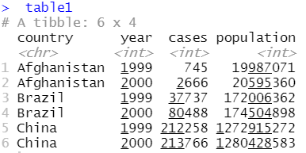

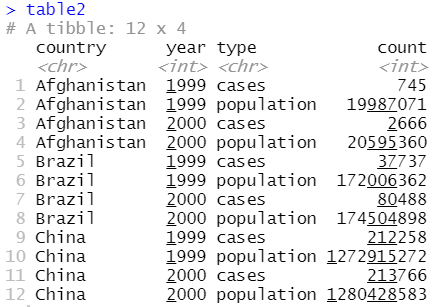

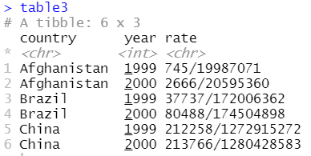

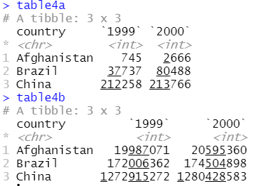

**Pivot Longer**

[figure not shown]

```r
table4a %>%
  pivot_longer(c(`1999`, `2000`), names_to = "year", values_to = "cases")
```

**Pivot wider**

[figure not shown]

```r
table2 %>%
  pivot_wider(names_from = type, values_from = count)
```

**Separating**

[figure not shown]

```r
table3 %>%
  separate(col = rate, into = c("cases", "population"), sep = "/")
```

```r
table3 %>%
  separate(col = rate, into = c("cases", "population"), sep = "/")
```

```
## # A tibble: 6 x 4
##   country      year cases  population
##   <chr>       <int> <chr>  <chr>
## 1 Afghanistan  1999 745    19987071
## 2 Afghanistan  2000 2666   20595360
## 3 Brazil       1999 37737  172006362
## 4 Brazil       2000 80488  174504898
## 5 China        1999 212258 1272915272
## 6 China        2000 213766 1280428583
```

```r
table3 %>%
  separate(col = rate, into = c("cases", "population"), sep = "/", convert = TRUE)
```

```
## # A tibble: 6 x 4
##   country      year  cases population
##   <chr>       <int>  <int>      <int>
## 1 Afghanistan  1999    745   19987071
## 2 Afghanistan  2000   2666   20595360
## 3 Brazil       1999  37737  172006362
## 4 Brazil       2000  80488  174504898
## 5 China        1999 212258 1272915272
## 6 China        2000 213766 1280428583
```